# Supervised Learning - Foundations Project: ReCell

## Problem Statement

### Business Context

Buying and selling used phones and tablets used to be something that happened on a handful of online marketplace sites. But the used and refurbished device market has grown considerably over the past decade, and a new IDC (International Data Corporation) forecast predicts that the used phone market would be worth \$52.7bn by 2023 with a compound annual growth rate (CAGR) of 13.6% from 2018 to 2023. This growth can be attributed to an uptick in demand for used phones and tablets that offer considerable savings compared with new models.

Refurbished and used devices continue to provide cost-effective alternatives to both consumers and businesses that are looking to save money when purchasing one. There are plenty of other benefits associated with the used device market. Used and refurbished devices can be sold with warranties and can also be insured with proof of purchase. Third-party vendors/platforms, such as Verizon, Amazon, etc., provide attractive offers to customers for refurbished devices. Maximizing the longevity of devices through second-hand trade also reduces their environmental impact and helps in recycling and reducing waste. The impact of the COVID-19 outbreak may further boost this segment as consumers cut back on discretionary spending and buy phones and tablets only for immediate needs.

### Objective

The rising potential of this comparatively under-the-radar market fuels the need for an ML-based solution to develop a dynamic pricing strategy for used and refurbished devices. ReCell, a startup aiming to tap the potential in this market, has hired you as a data scientist. They want you to analyze the data provided and build a linear regression model to predict the price of a used phone/tablet and identify factors that significantly influence it.

### Data Description

The data contains the different attributes of used/refurbished phones and tablets. The data was collected in the year 2021. The detailed data dictionary is given below.

- brand_name: Name of manufacturing brand
- os: OS on which the device runs
- screen_size: Size of the screen in cm
- 4g: Whether 4G is available or not
- 5g: Whether 5G is available or not
- main_camera_mp: Resolution of the rear camera in megapixels
- selfie_camera_mp: Resolution of the front camera in megapixels
- int_memory: Amount of internal memory (ROM) in GB
- ram: Amount of RAM in GB
- battery: Energy capacity of the device battery in mAh
- weight: Weight of the device in grams
- release_year: Year when the device model was released
- days_used: Number of days the used/refurbished device has been used
- normalized_new_price: Normalized price of a new device of the same model in euros
- normalized_used_price: Normalized price of the used/refurbished device in euros

## Importing necessary libraries

```python
import numpy as np
import pandas as pd


import matplotlib.pyplot as plt
import seaborn as sns

from sklearn.model_selection import train_test_split


import statsmodels.api as sm

from sklearn.metrics import mean_absolute_error, mean_squared_error, r2_score

%matplotlib inline
```

## Loading the dataset

```python
from google.colab import drive
drive.mount('/content/drive')
```

```python
# read the data
df = pd.read_csv('/content/drive/MyDrive/used_device_data.csv')
# returns the first 5 rows
df.head()
```

|  | brand_name | os | screen_size | 4g | 5g | main_camera_mp | selfie_camera_mp | int_memory | ram | battery | weight | release_year | days_used | normalized_used_price | normalized_new_price |
| --- | --- | --- | --- | --- | --- | --- | --- | --- | --- | --- | --- | --- | --- | --- | --- |
| 0 | Honor | Android | 14.50 | yes | no | 13.0 | 5.0 | 64.0 | 3.0 | 3020.0 | 146.0 | 2020 | 127 | 4.307572 | 4.715100 |
| 1 | Honor | Android | 17.30 | yes | yes | 13.0 | 16.0 | 128.0 | 8.0 | 4300.0 | 213.0 | 2020 | 325 | 5.162097 | 5.519018 |
| 2 | Honor | Android | 16.69 | yes | yes | 13.0 | 8.0 | 128.0 | 8.0 | 4200.0 | 213.0 | 2020 | 162 | 5.111084 | 5.884631 |
| 3 | Honor | Android | 25.50 | yes | yes | 13.0 | 8.0 | 64.0 | 6.0 | 7250.0 | 480.0 | 2020 | 345 | 5.135387 | 5.630961 |
| 4 | Honor | Android | 15.32 | yes | no | 13.0 | 8.0 | 64.0 | 3.0 | 5000.0 | 185.0 | 2020 | 293 | 4.389995 | 4.947837 |

## Data Overview

- Observations
- Sanity checks

```python
df.info()
```

```
<class 'pandas.core.frame.DataFrame'>
RangeIndex: 3454 entries, 0 to 3453
Data columns (total 15 columns):
 #   Column                 Non-Null Count  Dtype
---  ------                 --------------  -----
 0   brand_name             3454 non-null   object
 1   os                     3454 non-null   object
 2   screen_size            3454 non-null   float64
 3   4g                     3454 non-null   object
 4   5g                     3454 non-null   object
 5   main_camera_mp         3275 non-null   float64
 6   selfie_camera_mp       3452 non-null   float64
 7   int_memory             3450 non-null   float64
 8   ram                    3450 non-null   float64
 9   battery                3448 non-null   float64
 10  weight                 3447 non-null   float64
 11  release_year           3454 non-null   int64
 12  days_used              3454 non-null   int64
 13  normalized_used_price  3454 non-null   float64
 14  normalized_new_price   3454 non-null   float64
dtypes: float64(9), int64(2), object(4)
memory usage: 404.9+ KB
```

## Exploratory Data Analysis (EDA)

- EDA is an important part of any project involving data.
- It is important to investigate and understand the data better before building a model with it.
- A few questions have been mentioned below which will help you approach the analysis in the right manner and generate insights from the data.
- A thorough analysis of the data, in addition to the questions mentioned below, should be done.

**Questions**:

1. What does the distribution of normalized used device prices look like?
2. What percentage of the used device market is dominated by Android devices?
3. The amount of RAM is important for the smooth functioning of a device. How does the amount of RAM vary with the brand?
4. A large battery often increases a device's weight, making it feel uncomfortable in the hands. How does the weight vary for phones and tablets offering large batteries (more than 4500 mAh)?
5. Bigger screens are desirable for entertainment purposes as they offer a better viewing experience. How many phones and tablets are available across different brands with a screen size larger than 6 inches?
6. A lot of devices nowadays offer great selfie cameras, allowing us to capture our favorite moments with loved ones. What is the distribution of devices offering greater than 8MP selfie cameras across brands?
7. Which attributes are highly correlated with the normalized price of a used device?

Question 1: What does the distribution of normalized used device prices look like

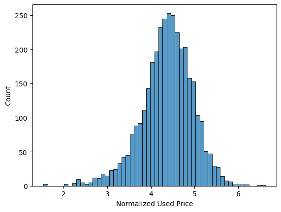

```python
sns.histplot(data = df, x = 'normalized_used_price')
plt.xlabel("Normalized Used Price")
```

Question 2: What percentage of the used device market is dominated by Android devices?

```python
AndroidList = 0
for i in df['os']:
  if i == "Android":
    AndroidList += 1

print((AndroidList/3454) * 100)
```

```
93.05153445280834
```

Question 3: The amount of RAM is important for the smooth functioning of a device. How does the amount of RAM vary with the brand?

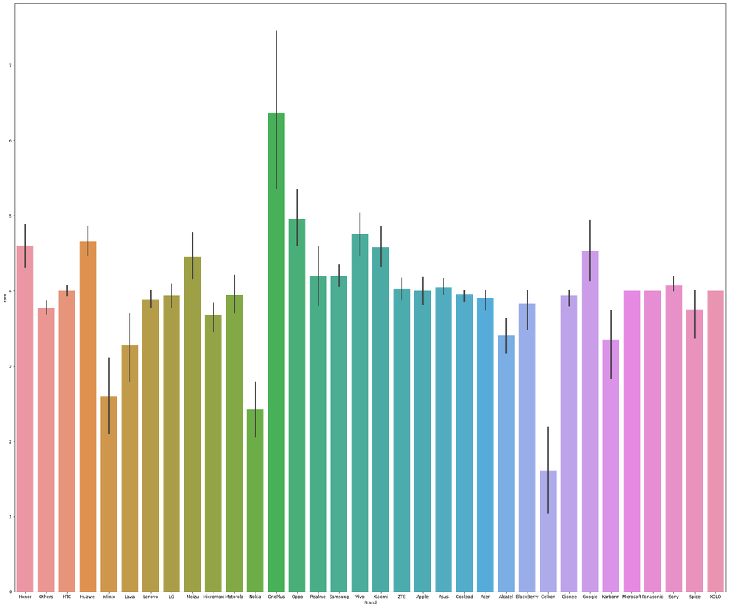

```python
plt.figure(figsize = (30,25))
sns.barplot(data = df, x = 'brand_name', y = 'ram')
plt.xlabel('Brand')
plt.show()
```

Question 4:

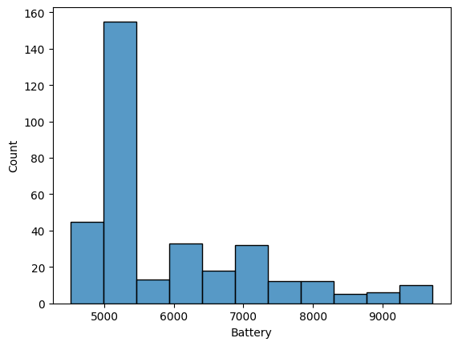

```python
batteryOver4500 = []
for i in df["battery"]:
  if i > 4500:
    batteryOver4500.append(i)
batteryDataFrame = pd.DataFrame({'battery': batteryOver4500})
sns.histplot(data = batteryDataFrame, x = 'battery')
plt.xlabel('Battery')
```

## Data Preprocessing

- Missing value treatment
- Feature engineering (if needed)
- Outlier detection and treatment (if needed)
- Preparing data for modeling
- Any other preprocessing steps (if needed)

```python
df1 = df.copy()
```

```python
df1.isnull().sum()
```

```
brand_name                 0
os                         0
screen_size                0
4g                         0
5g                         0
main_camera_mp           179
selfie_camera_mp           2
int_memory                 4
ram                        4
battery                    6
weight                     7
release_year               0
days_used                  0
normalized_used_price      0
normalized_new_price       0
dtype: int64
```

```python
mcmpMedian  = df1['main_camera_mp'].median()
df1['main_camera_mp'] = df1['main_camera_mp'].fillna(mcmpMedian)
```

```python
scmpMedian  = df1['selfie_camera_mp'].median()
df1['selfie_camera_mp'] = df1['selfie_camera_mp'].fillna(scmpMedian)
```

```python
intmemMedian  = df1['int_memory'].median()
df1['int_memory'] = df1['int_memory'].fillna(intmemMedian)
```

```python
ramMedian  = df1['ram'].median()
df1['ram'] = df1['ram'].fillna(ramMedian)
```

```python
batteryMedian  = df1['battery'].median()
df1['battery'] = df1['battery'].fillna(batteryMedian)
```

```python
weightMedian  = df1['weight'].median()
df1['weight'] = df1['weight'].fillna(weightMedian)
```

## EDA

- It is a good idea to explore the data once again after manipulating it.

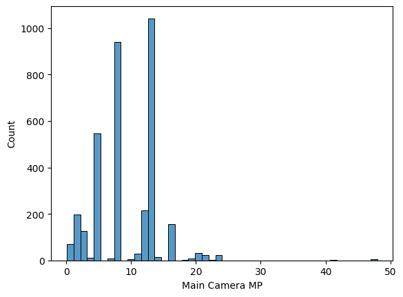

```python
sns.histplot(data = df1, x = 'main_camera_mp')
plt.xlabel('Main Camera MP')
```

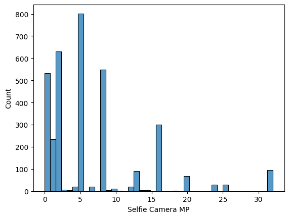

```python
sns.histplot(data = df1, x = 'selfie_camera_mp')
plt.xlabel('Selfie Camera MP')
```

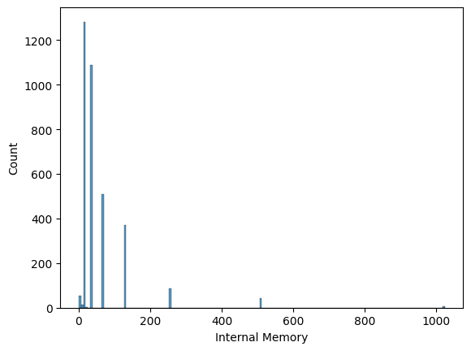

```python
sns.histplot(data = df1, x = 'int_memory')
plt.xlabel('Internal Memory')
```

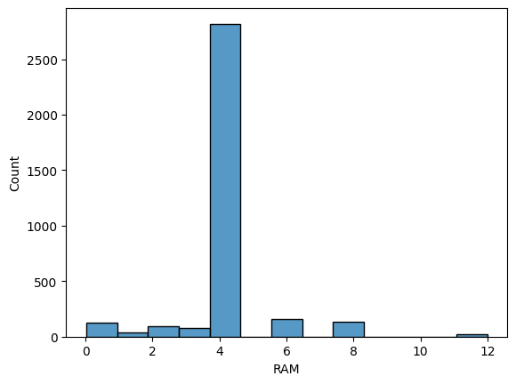

```python
sns.histplot(data = df1, x = 'ram')
plt.xlabel('RAM')
```

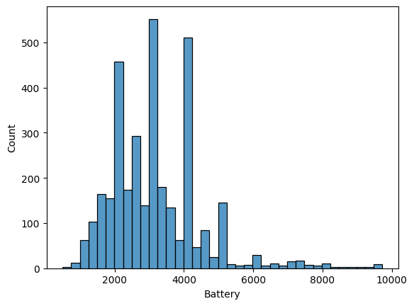

```python
sns.histplot(data = df1, x = 'battery')
plt.xlabel('Battery')
```

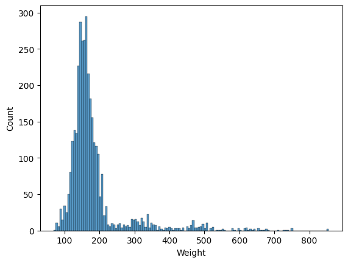

```python
sns.histplot(data = df1, x = 'weight')
plt.xlabel('Weight')
```

## Model Building - Linear Regression

```python
from pandas.core.indexes import category
X = df1.drop(["normalized_used_price"], axis = 1)
y = df1[["normalized_used_price"]]
```

```python
X = sm.add_constant(X)
```

```python
X = pd.get_dummies(
    X,
    columns = X.select_dtypes(include=["object", "category"]).columns.tolist(), drop_first=True)
X.head()
```

|  | const | screen_size | main_camera_mp | selfie_camera_mp | int_memory | ram | battery | weight | release_year | days_used | ... | brand_name_Spice | brand_name_Vivo | brand_name_XOLO | brand_name_Xiaomi | brand_name_ZTE | os_Others | os_Windows | os_iOS | 4g_yes | 5g_yes |
| --- | --- | --- | --- | --- | --- | --- | --- | --- | --- | --- | --- | --- | --- | --- | --- | --- | --- | --- | --- | --- | --- |
| 0 | 1.0 | 14.50 | 13.0 | 5.0 | 64.0 | 3.0 | 3020.0 | 146.0 | 2020 | 127 | ... | 0 | 0 | 0 | 0 | 0 | 0 | 0 | 0 | 1 | 0 |
| 1 | 1.0 | 17.30 | 13.0 | 16.0 | 128.0 | 8.0 | 4300.0 | 213.0 | 2020 | 325 | ... | 0 | 0 | 0 | 0 | 0 | 0 | 0 | 0 | 1 | 1 |
| 2 | 1.0 | 16.69 | 13.0 | 8.0 | 128.0 | 8.0 | 4200.0 | 213.0 | 2020 | 162 | ... | 0 | 0 | 0 | 0 | 0 | 0 | 0 | 0 | 1 | 1 |
| 3 | 1.0 | 25.50 | 13.0 | 8.0 | 64.0 | 6.0 | 7250.0 | 480.0 | 2020 | 345 | ... | 0 | 0 | 0 | 0 | 0 | 0 | 0 | 0 | 1 | 1 |
| 4 | 1.0 | 15.32 | 13.0 | 8.0 | 64.0 | 3.0 | 5000.0 | 185.0 | 2020 | 293 | ... | 0 | 0 | 0 | 0 | 0 | 0 | 0 | 0 | 1 | 0 |

5 rows × 49 columns

```python
X_train, X_test, y_train, y_test = train_test_split(X, y, train_size = 0.7, random_state = 1)
```

```python
model = sm.OLS(y_train, X_train).fit()
print(model.summary())
```

```
                              OLS Regression Results
=================================================================================
Dep. Variable:     normalized_used_price   R-squared:                       0.845
Model:                               OLS   Adj. R-squared:                  0.842
Method:                    Least Squares   F-statistic:                     268.8
Date:                   Sat, 18 Nov 2023   Prob (F-statistic):               0.00
Time:                           02:10:51   Log-Likelihood:                 124.22
No. Observations:                   2417   AIC:                            -150.4
Df Residuals:                       2368   BIC:                             133.3
Df Model:                             48
Covariance Type:               nonrobust
=========================================================================================
                            coef    std err          t      P>|t|      [0.025      0.975]
-----------------------------------------------------------------------------------------
const                   -48.6977      9.184     -5.303      0.000     -66.707     -30.689
screen_size               0.0243      0.003      7.145      0.000       0.018       0.031
main_camera_mp            0.0203      0.001     13.806      0.000       0.017       0.023
selfie_camera_mp          0.0136      0.001     12.084      0.000       0.011       0.016
int_memory                0.0001   6.97e-05      1.542      0.123   -2.92e-05       0.000
ram                       0.0239      0.005      4.657      0.000       0.014       0.034
battery               -1.585e-05   7.27e-06     -2.181      0.029   -3.01e-05    -1.6e-06
weight                    0.0010      0.000      7.421      0.000       0.001       0.001
release_year              0.0248      0.005      5.441      0.000       0.016       0.034
days_used              3.485e-05   3.09e-05      1.127      0.260   -2.58e-05    9.55e-05
normalized_new_price      0.4310      0.012     35.133      0.000       0.407       0.455
brand_name_Alcatel        0.0153      0.048      0.321      0.748      -0.078       0.109
brand_name_Apple         -0.0116      0.147     -0.079      0.937      -0.300       0.277
brand_name_Asus           0.0195      0.048      0.408      0.683      -0.074       0.113
brand_name_BlackBerry    -0.0295      0.070     -0.420      0.675      -0.167       0.108
brand_name_Celkon        -0.0424      0.066     -0.640      0.522      -0.172       0.088
brand_name_Coolpad        0.0401      0.073      0.551      0.582      -0.103       0.183
brand_name_Gionee         0.0454      0.058      0.787      0.431      -0.068       0.159
brand_name_Google        -0.0312      0.085     -0.369      0.712      -0.197       0.135
brand_name_HTC           -0.0115      0.048     -0.240      0.811      -0.106       0.083
brand_name_Honor          0.0244      0.049      0.496      0.620      -0.072       0.121
brand_name_Huawei        -0.0081      0.044     -0.181      0.856      -0.095       0.079
brand_name_Infinix        0.1548      0.093      1.661      0.097      -0.028       0.337
brand_name_Karbonn        0.0971      0.067      1.447      0.148      -0.034       0.229
brand_name_LG            -0.0152      0.045     -0.335      0.738      -0.104       0.074
brand_name_Lava           0.0337      0.062      0.541      0.589      -0.089       0.156
```

[output cut: 19 more lines]

```
os_Windows               -0.0176      0.045     -0.389      0.697      -0.106       0.071
os_iOS                   -0.0585      0.146     -0.399      0.690      -0.346       0.229
4g_yes                    0.0507      0.016      3.190      0.001       0.020       0.082
5g_yes                   -0.0435      0.032     -1.369      0.171      -0.106       0.019
==============================================================================
Omnibus:                      217.620   Durbin-Watson:                   1.904
Prob(Omnibus):                  0.000   Jarque-Bera (JB):              409.702
Skew:                          -0.607   Prob(JB):                     1.08e-89
Kurtosis:                       4.611   Cond. No.                     7.69e+06
==============================================================================

Notes:
[1] Standard Errors assume that the covariance matrix of the errors is correctly specified.
[2] The condition number is large, 7.69e+06. This might indicate that there are
strong multicollinearity or other numerical problems.
```

## Model Performance Check

```python
predictions = model.predict(X_train)
r2 = r2_score(y_train, predictions)
n = X_train.shape[0]
k = X_train.shape[1]
adjustedR2 = 1 - ((1 - r2) * (n - 1) / (n - k - 1))

print("The Adjusted R2 is: " + str(adjustedR2))
```

```
The Adjusted R2 is: 0.8417232862807771
```